# Decap CMS & Astro

[Decap CMS](https://www.decapcms.org/) (formerly Netlify CMS) is an open-source, Git-based content management system.

Decap allows you to take full advantage of all of Astro’s features, including image optimization and content collections.

Decap adds a route (typically `/admin`) to your project that will load a React app to allow authorized users to manage content directly from the deployed website. Decap will commit changes directly to your Astro project’s source repository.

## Installing DecapCMS

There are two options for adding Decap to Astro:

1. [Install Decap via a package manager](https://decapcms.org/docs/install-decap-cms/#installing-with-npm) with the following command:

   ```
   npm install decap-cms-app
   ```

2. Import the package into a `<script>` tag in your page `<body>`

   /admin

   ```
   <body>
     <!-- Include the script that builds the page and powers Decap CMS -->
     <script src="https://unpkg.com/decap-cms@^3.1.2/dist/decap-cms.js"></script>
   </body>
   ```

## Configuration

1. Create a static admin folder at `public/admin/`
2. Add `config.yml` to `public/admin/`:
   - **public**
     - **admin**
       - config.yml
3. To add support for content collections, configure each schema in `config.yml`. The following example configures a `blog` collection, defining a `label` for each entry’s frontmatter property:

   /public/admin/config.yml

   ```
   collections:
     - name: "blog" # Used in routes, e.g., /admin/collections/blog
       label: "Blog" # Used in the UI
       folder: "src/content/blog" # The path to the folder where the documents are stored
       create: true # Allow users to create new documents in this collection
       fields: # The fields for each document, usually in frontmatter
         - { label: "Layout", name: "layout", widget: "hidden", default: "blog" }
         - { label: "Title", name: "title", widget: "string" }
         - { label: "Publish Date", name: "date", widget: "datetime" }
         - { label: "Featured Image", name: "thumbnail", widget: "image" }
         - { label: "Rating (scale of 1-5)", name: "rating", widget: "number" }
         - { label: "Body", name: "body", widget: "markdown" }
   ```

4. Add the `admin` route for your React app in `src/pages/admin.html`.
   - **public**
     - **admin**
       - config.yml
   - **src**
     - **pages**
       - admin.html

5. To enable media uploads to a specific folder via the Decap editor, add an appropriate path:

   /public/admin/config.yml

   ```
   media_folder: "src/assets/images" # Location where files will be stored in the repo
   public_folder: "src/assets/images" # The src attribute for uploaded media
   ```

See [the Decap CMS configuration documentation](https://decapcms.org/docs/configure-decap-cms/) for full instructions and options.

## Usage

Navigate to `yoursite.com/admin/` to use the Decap CMS editor.

## Authentication

### Decap CMS with Netlify Identity

Decap CMS was originally developed by Netlify and has first class support for [Netlify Identity](https://docs.netlify.com/security/secure-access-to-sites/identity/).

When deploying to Netlify, configure Identity for your project via the Netlify dashboard and include the [Netlify Identity Widget](https://github.com/netlify/netlify-identity-widget) on the `admin` route of your project. Optionally include the Identity Widget on the homepage of your site if you plan to invite new users via email.

### Decap CMS with External OAuth Clients

When deploying to hosting providers other than Netlify, you must create your own OAuth routes.

In Astro, this can be done with on-demand rendered routes in your project configured with an adapter enabled.

See [Decap’s OAuth Docs](https://decapcms.org/docs/external-oauth-clients/) for a list of compatible community-maintained OAuth clients.

## Community Resources

- Netlify Identity Template: [astro-decap-ssg-netlify](https://github.com/OliverSpeir/astro-decap-ssg-netlify-identity)
- On-demand rendering OAuth Routes with Astro Template: astro-decap-starter-ssr
- Blog Post: [Author your Astro site’s content with Git-based CMSs](https://aalam.vercel.app/blog/astro-and-git-cms-netlify) by Aftab Alam
- Youtube Tutorial: [Create a Custom Blog with Astro & NetlifyCMS in MINUTES!](https://www.youtube.com/watch?v=3yip2wSRX_4) by Kumail Pirzada

## Production Sites

The following sites use Astro + Decap CMS in production:

- [yunielacosta.com](https://www.yunielacosta.com/) by Yuniel Acosta — [source code on GitHub](https://github.com/yacosta738/yacosta738.github.io) (Netlify CMS)
- [portfolioris.nl](https://www.portfolioris.nl/) by Joris Hulsbosch – [source code on GitHub](https://github.com/portfolioris/portfolioris.nl)

## Themes

[figure not shown]

- Astros

[figure not shown]

- Enhanced Astro Starter

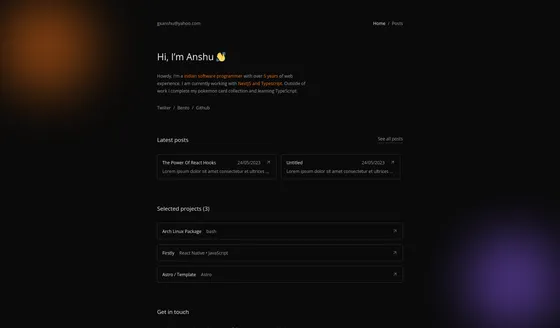

- Astro Decap CMS Starter

[figure not shown]